# Single cell - Pseudotime (AML + healthy)

17 October 25

*** refer to src/preprocess/6.scrna_vg_preprocess.Rmd for preprocessing and clustering - re-clustering using seurat v5 for more efficient processing - seurat v5 was converted to v3 assay class for seurat 4.3.0 compatibility

# 35 AML samples (N=12) + 5 healthy samples (N=5)

*** currently contains all longitudinal samples

“AML1012” “AML210A”  
“AML328”  
“AML329”  
“AML419A” “AML420B” “AML475”  
“AML556”  
“AML707B” “AML870”  
“AML916”  
“AML921A”  
“BM1”  
“BM2”  
“BM3”  
“BM4”  
“BM5”

To remove as described in van galen et al 2019 “AML314”, “AML371”, “AML722B”, “AML997”

# library

```r
library(tidyverse)
library(Seurat)

library(slingshot)
library(tradeSeq)
# library(SeuratExtend)

library(ComplexHeatmap)
library(RColorBrewer)
library(patchwork)

library(ggpubr)
library(rstatix)

source("src/function/scrna_colour.R")
source("src/function/loading_data.R")
set.seed(10)

set_alpha <- function(plot, alpha = 0.7){
  for (i in 1:length(plot)) {
    plot[[i]]$layers[[1]]$aes_params$alpha =  alpha
  }
  return(plot)
}
```

# loading overall

```r
all_ <- readRDS(file="data/scrna/all_v3.rds")
reference <- read.csv("data/inflammatory_sig_246.csv")
```

# plots

## fig 6a: overall umap

```r
p <- DimPlot(all_, reduction = "umap", group.by="CellType", shape.by = "cell_status",
        cols = hierarchy_colors, pt.size=.5, shuffle = T) %>%
  set_alpha() +
  scale_shape_manual(values = c(17,16,15), name = NULL,
                     labels = c("AML_malignant\n(n=13,489)",
                                "AML_nonmalignant\n(n=15,333)",
                                "Healthy_normal\n(n=6,915)")) +
  theme(aspect.ratio = 1) + ggtitle("") +
  guides(shape = guide_legend(override.aes = list(size = 3, alpha = 1)),
         color = guide_legend(override.aes = list(size = 3, alpha = 1)) ) &
  theme_pdf

ggsave(plot = p,"plot/fig6/main_6a_umap_overall.png", width = 7.5, height = 6, dpi = 600, bg = "transparent")
ggsave(plot = p,"plot/fig6/main_6a_umap_overall.pdf", width = 7.5, height = 6, bg = "transparent", device = cairo_pdf)
```

```r
p <- DimPlot(all_, reduction = "umap", group.by = c("PatientID", "seurat_clusters")) + DimPlot(all_, reduction = "umap", group.by = c( "CellType"), cols =  hierarchy_colors, combine = F)

p <- p %>%
  set_alpha() &
  guides(color = guide_legend(override.aes = list(size = 3, alpha = 1)) ) &
  theme_pdf

ggsave(plot = p,"plot/suppfig7/supp_7a_afterbc_all_2.png", width=20, height=5, dpi = 600, bg = "transparent")
ggsave(plot = p,"plot/suppfig7/supp_7a_afterbc_all_2.pdf", width=20, height=5, bg = "transparent", device = cairo_pdf)
```

## fig 6b: split by cell status (top)

```r
ob_list <- SplitObject(all_, split.by = "cell_status")

p <- lapply(X = ob_list, FUN = function(x) {

    DimPlot(x, reduction = "umap", group.by="CellType", split.by = "cell_status",
            cols = hierarchy_colors, pt.size=.5) %>%
      set_alpha() +
      theme(aspect.ratio = 1, strip.text = element_text(size = 14),
            legend.key.height = unit(0.5, "cm")) + ggtitle("") +
      guides(color = guide_legend(override.aes = list(size = 3, alpha = 1)) )
})

p <- p[[2]] + p[[1]] + p[[3]] + patchwork::plot_layout(ncol = 3, guides = "collect") &
  theme_pdf

ggsave(plot = p,"plot/fig6/main_6b_umap_celltype.png", width = 15, height = 5, dpi = 600)
ggsave(plot = p,"plot/fig6/main_6b_umap_celltype.pdf", width = 15, height = 5, bg = "transparent", device = cairo_pdf)
```

## fig 6b: inflammation (middle)

```r
p <- FeaturePlot(all_, reduction = "umap",
                 split.by = "cell_status", features = "Inflammation",
                 pt.size = .8, order=TRUE, keep.scale = "feature") %>%
  set_alpha()  &
  scale_colour_gradientn(colours = rev(brewer.pal(n = 11, name = "Spectral")),
                         limits=c(-0.15,1), name = "Inflammatory\nScore") &
  theme(axis.title = element_text(size = 14), aspect.ratio = 1,
        title = element_text(size = 12),
        axis.title.y.right = element_blank()
        )

p <- p + theme(legend.position = "right") & theme_pdf

ggsave(plot = p,"plot/fig6/main_6b_dimplot_infl.png", width = 14, height = 5, dpi = 600)
ggsave(plot = p,"plot/fig6/main_6b_dimplot_infl.pdf", width = 14, height = 5, bg = "transparent", device = cairo_pdf)
```

## fig 6b: boxplot of inflammation scores per cell per cell type (bottom)

```r
df <- FetchData(all_, vars = c("cell_status", "celltype", "CellType", "Inflammation"))
p <- ggplot(df, aes(x = celltype, y = Inflammation, fill = CellType)) +
  geom_boxplot() +
  scale_fill_manual(values = hierarchy_colors, guide = "none") +
  theme_classic(base_size = 12) +
  labs(x="", y="Inflammatory Score")+
  facet_grid(~cell_status, drop = T, axes = "all") +
  theme(axis.text.x = element_text(angle = 90, vjust = 0.5, hjust = 1),
        aspect.ratio = 0.5) +
  theme_pdf

ggsave(plot = p,"plot/fig6/main_6b_boxplot_infl.png", width = 12, height = 3, dpi = 600)
ggsave(plot = p,"plot/fig6/main_6b_boxplot_infl.pdf", width = 12, height = 3, bg = "transparent", device = cairo_pdf)
```

## difference between patients

- annotated based on distribution of each cell subpopulations
  - primitive-like - when HSC, Prog and GMP are most of the malignant cells
  - mature-like - when ProMono, Mono and cDC are most of the malignant cells
- caveat: AML329 - though diagnosis was “monocytic”, was annotated as primitive like

```r
df <- all_@meta.data %>%
  select(SampleID := orig.ident, PatientID, CellType, cell_status) %>%
  group_by(SampleID, CellType, cell_status, PatientID) %>%
  summarise(n = n()) %>%
  group_by(SampleID, cell_status) %>%
  mutate(total = sum(n),
         PercentDist = (n/total)*100,
         CellType = factor(CellType, levels = rev(unique(CellType))) ) %>%
  ungroup() %>%
  mutate(Day = gsub(".*-D", "", SampleID))

write.csv(df, "output/supp/scrna/scrna_cell_dist_per_sampleid.csv", row.names = F)
```

```r
patient_order <- read.csv("data/scrna/vangalen_sampleinfo.csv") %>%
  filter(Sample %in% unique(all_$PatientID)) %>%
  select(SampleID, Sample, Day := Days.from.Diagnosis, AML_subtype, Category) %>%
  slice_min(order_by = Day, n=1) %>% arrange(desc(Category), SampleID)

df <- read.csv("output/supp/scrna/scrna_cell_dist_per_sampleid.csv", check.names = F)
df_1 <- df %>%
  mutate(
    category = case_when(
      CellType %in% c("HSC-like", "Prog-like", "HSC", "Prog") ~ "primitive",
      CellType %in% c("ProMono-like", "Mono-like", "cDC-like", "ProMono", "Mono", "cDC") ~ "mature",
      CellType %in% c("GMP-like", "GMP") ~ "GMP",
      CellType %in% c('ProB', 'B', 'Plasma', 'T', 'CTL', 'NK') ~ "lymphoid",
      CellType %in% c('earlyEry', 'lateEry') ~ "erythroid",
      .default = CellType
    )
  ) %>%
  group_by(SampleID, category, cell_status, total, Day) %>%
  summarise(n = sum(n)) %>%
  group_by(SampleID, cell_status) %>%
  mutate(PercentDist = (n/total)*100) %>%
  filter(Day == "0") %>%
  arrange(PercentDist) %>%
  mutate(SampleID = factor(SampleID, levels = patient_order$SampleID))
p <- df_1 %>%
  mutate(category = factor(category, levels = c("primitive", "GMP", "mature", "lymphoid", "erythroid", "pDC"))
         ) %>%
ggplot(. , aes(x = cell_status, y = PercentDist, fill = category)) +
  geom_col(aes (color = cell_status), position = "stack", width = 0.7, linewidth = 1.5) +
  geom_col(position = "stack", width = 0.6, linewidth = 1) +
  geom_text(
      aes(label = ifelse(PercentDist>2, paste0(round(PercentDist,1)), "" ) ),
      position = position_stack(vjust = 0.5), size = 3,color = "black"
  ) +

  scale_color_manual(values = c("red", "royalblue")) +
  scale_fill_manual(
    values = c(primitive = "#ce9866", GMP = "#FDB462",
               mature = "#B3DE69", lymphoid = "#BEBADA",
               erythroid = "#F781BF", pDC = "#8DD3C7"),
    labels = c("primitive\n(HSC, Prog)", "GMP", "mature\n(ProMono, Mono, cDC)",
               "lymphoid\n(ProB, B, Plasma, T, CTL, NK)",
               "erythroid", "pDC") ) +
  scale_y_continuous(expand = c(0, 1)) +
  labs(y = "Percent Distribution (%)", x = "Patient Sample (Day 0)") +
  facet_wrap(~SampleID, ncol = 6, strip.position = "bottom",
             labeller = labeller(SampleID = function(x) gsub("-D0", "", x)) ) +
  theme_classic() +
  theme(axis.text.x = element_blank(), axis.ticks.x = element_blank(),
        legend.key.size = unit(0.3, "cm"), aspect.ratio = 2.5,
        legend.position = "bottom", legend.direction = "vertical") +
  theme_pdf

ggsave(plot = p,"plot/fig6/main_6c_cellpop_D0.png", width = 7, height = 6, dpi = 600)
ggsave(plot = p,"plot/fig6/main_6c_cellpop_D0.pdf", width = 7, height = 6, bg = "transparent", device = cairo_pdf)
```

```r
temp <- all_@meta.data %>%
  select(SampleID := orig.ident, PatientID, CellType, cell_status, Inflammation) %>%
  rownames_to_column("cell.barcode") %>%
  mutate(Day = gsub(".*-D", "", SampleID) ) %>%
  group_by(SampleID, Day) %>% # overall inflammation score per patient
  summarise(Inflammation = mean(Inflammation)) %>%
  filter(Day == "0") %>%
  inner_join(., df_1)
p <- temp %>%
  # filter(category %in% c("primitive", "GMP", "mature")) %>% # main fig
  filter(!category %in% c("primitive", "GMP", "mature")) %>% # supp fig
  mutate(category = factor(category, levels = c("primitive", "GMP", "mature", "lymphoid", "erythroid", "pDC")),
         SampleID = factor(SampleID, levels = patient_order$SampleID)
         ) %>%
ggplot(., aes(x = PercentDist, y = Inflammation)) +
  geom_smooth(method = "lm", color = "black", se = F, size = 0.5) +
  stat_cor(method = "spearman", size = 3) +
  geom_point(aes(fill = SampleID), size = 2, alpha = .9, shape = 21, color = "grey10") +
  scale_fill_brewer(palette = "Paired") +
  theme_classic(base_size = 12) +
  labs(x="Percent Distribution (%)", y = "Mean Inflammatory Score") +
  facet_grid(category~cell_status, drop = T, axes = "all") +
  theme(axis.text.x = element_text(angle = 90, vjust = 0.5, hjust = 1),
        aspect.ratio = 0.5, legend.key.size = unit(0.3, "cm")) +
  theme_pdf

# ggsave(plot = p,"plot/fig6/main_6d_cellpop_inflam_main.png", width = 7, height = 6, dpi = 600)
# ggsave(plot = p,"plot/fig6/main_6d_cellpop_inflam_main.pdf", width = 7, height = 6, bg = "transparent", device = cairo_pdf)

ggsave(plot = p,"plot/suppfig7/supp_7b_cellpop_inflam_supp.png", width = 4.5, height = 6, dpi = 600)
ggsave(plot = p,"plot/suppfig7/supp_7b_cellpop_inflam_supp.pdf", width = 4.5, height = 6, bg = "transparent", device = cairo_pdf)
```

# DEG: Differential between malignant and normal

- limiting to AML samples
- limiting to myeloid-monocytic lineage; excluding eryth
- refer to src/preprocess/6.scrna_mast.R

```r
selected <- subset(all_, subset = celltype %in% c("GMP", "Prog", "ProMono", "HSC", "cDC", "Mono"))
```

- identifying genes/programs difference between the 2 differentiation stage
- Malignant Mature-like vs. Malignant Primitive-like
- Nonmalignant Mature-like vs. Nonmalignant Primitive-like
- Normal Mature-like vs. Normal Primitive-like

- identifying genes/programs difference between the cell types in mature myeloid compartments (“ProMono”, “Mono”, “cDC”)
- Mature-like Malignant vs. Mature-like Normal
- Mature-like Nonmalignant vs. Mature-like Normal
- Mature-like Nonmalignant vs. Mature-like Malignant

# Trajectory inference analysis

## slingshot

- limiting to AML samples
- limiting to myeloid-monocytic lineage; excluding eryth
- table(selected$seurat_clusters) 0 1 2 3 4 5 6 7 8 9 10 11 12 13 14 15 7421 33 4779 3979 10 1789 92 1297 41 921 352 7 247 256 35 89 16 59
  - 1, 4, 6, 8, 11, 14, 15, 16 - removed for small cluster size (<100)
  - 10 was removed due to overlaps with erythroid pop; 12 removed due to distinctness from other HSC pop

(n=20442 after filtering) AML_malignant AML_nonmalignant Healthy_normal 12826 3376 4240

```r
table(selected$seurat_clusters)
table(selected$celltype, selected$seurat_clusters)

(DimPlot(selected, reduction = "umap", label = T, pt.size = .5, group.by = c("seurat_clusters")) + DimPlot(selected, reduction = "umap", label = T, pt.size = .5, group.by = c( "CellType"), cols = hierarchy_colors)) %>% set_alpha() & theme(aspect.ratio = 1, legend.position = "none")
# ggsave("plot/other/selected_bf_drop.png", width = 11, height = 5, dpi = 400)

## removing small clusters
clusters_to_remove <- c(1, 4, 6, 8, 10, 11, 12, 14, 15, 16)
selected <- subset(selected, subset = seurat_clusters %in% clusters_to_remove, invert = TRUE)
selected$seurat_clusters <- droplevels(selected$seurat_clusters)

(DimPlot(selected, reduction = "umap", label = T, pt.size = .5, group.by = c("seurat_clusters")) + DimPlot(selected, reduction = "umap", label = T, pt.size = .5, group.by = c( "CellType"), cols = hierarchy_colors)) %>% set_alpha() & theme(aspect.ratio = 1, legend.position = "none")
# ggsave("plot/other/selected_af_drop.png", width = 11, height = 5, dpi = 400)

saveRDS(selected, "output/rds/scrna_selected_obj.rds")
```

```r
pto <- slingshot(Embeddings(selected, "umap"),
                        clusterLabels = selected$seurat_clusters,
                        start.clus = 0, end.clus = c(7,13)) #


saveRDS(pto, "output/rds/scrna_selected_pseudotime_slingshot.rds")
```

## Trade-seq: Trajectory inference analysis

```r
counts_filt <- FetchData(selected, vars=VariableFeatures(selected), layer="counts")
counts_filt <- t(counts_filt)

BPPARAM <- BiocParallel::SnowParam(workers = 8, progressbar = TRUE)

sce <- fitGAM(counts = counts_filt,
             sds = pto,
             parallel=TRUE,
             BPPARAM = BPPARAM,
             nknots = 6) # Reduced nknots slightly for speed if needed

saveRDS(sce, "output/rds/scrna_selected_pseudotime_fitGAM.rds")
```

- within lineage comparisons
  - associationTest: assesses whether average gene expression is associated with pseudotime - a particular lineage
- Between-lineage comparisons
  - patternTest: implements a statistical method that checks whether the smoothed gene expression is equal along pseudotime between two or multiple lineages.

```r
associationTest(sce, lineages = T) %>%
  rownames_to_column("feature_id") %>%
  arrange(-waldStat, -meanLogFC) %>%
  write.csv(., "output/supp/scrna/selected_avgGE_assoc_pseudotime.csv", row.names = F)

patternTest(sce, global = TRUE, pairwise = TRUE) %>%
  rownames_to_column("feature_id") %>%
  filter(pvalue < 0.05, !is.na(pvalue)) %>%
  arrange(-waldStat) %>%
  write.csv(., "output/supp/scrna/selected_patterntest.csv", row.names = F)
```

# plots & tbl

## load data

```r
load_pseudotime_data <- function() {
  all_selected <- readRDS("output/rds/scrna_selected_obj.rds")
  pto <- readRDS("output/rds/scrna_selected_pseudotime_slingshot.rds")
  sce <- readRDS("output/rds/scrna_selected_pseudotime_fitGAM.rds")
  cluster_name <- c(`0` = "HSC", `3` = "Prog", `9` = "GMP", `5` = "ProMono", `2` = "Mono", `7` = "cDC", `13` = "Mono")

  filt_counts <- FetchData(all_selected, vars = VariableFeatures(all_selected), layer="counts")
  sds <- SlingshotDataSet(pto)
  time <- slingAvgPseudotime(pto)

  df <- data.frame(slingReducedDim(sds),
                   cl = all_selected@meta.data$seurat_clusters,
                   pseudotime = time,
                   celltype = all_selected$CellType) %>%
    mutate(cluster = as.character(as.numeric(cl)))

  curves <- slingCurves(sds, as.df = TRUE)
  mst <- slingMST(sds, as.df = TRUE)
  mst$cluster_name <- cluster_name[mst$Cluster]

  all_selected$pseudotime <- time

  cluster_centers <- df %>%
    group_by(celltype) %>%
    summarize(umap_1 = median(umap_1), umap_2 = median(umap_2))

  return(list(
    all_selected = all_selected,
    pto = pto,
    sce = sce,
    filt_counts = filt_counts,
    sds = sds,
    time = time,
    df = df,
    curves = curves,
    mst = mst,
    cluster_name = cluster_name,
    cluster_centers = cluster_centers
  ))
}
```

Lineage cluster_name  
1 Lineage1 Lineage -> cDC 2 Lineage2 Lineage -> Mono 3 Lineage3 Lineage -> GMP

```r
pseudotime_list <- load_pseudotime_data()
list2env(pseudotime_list, envir = .GlobalEnv)
```

```
<environment: R_GlobalEnv>
```

```r
HVGs <- VariableFeatures(all_selected)

pseudotime_association <- read.csv("output/supp/scrna/selected_avgGE_assoc_pseudotime.csv") %>%
  filter(pvalue_1 < 0.01 | pvalue_2 < 0.01 | pvalue_3 < 0.01)

patternRes <- read.csv("output/supp/scrna/selected_patterntest.csv")
```

## tbl 19: overlapping DEG and pseudotime outcomes

- filters at least one comparison has p_adj < 0.05, lfc = 0.58

```r
# 1) Read DEG table + add significance flag
read_deg <- function(path, p_adj = 0.05, lfc = 0.58) {
  read.csv(path) %>%
    mutate(sig = p_val_adj < p_adj & abs(avg_log2FC) > lfc) %>%
    arrange(avg_log2FC, p_val_adj)
}

# requires reference, HVGs, pseudotime_association, patternRes
# 2) Build 3-way overlap + labels + "same direction" + common annotations
make_overlap_df <- function(a, b, c, set_map) {
  a <- read_deg(a)
  b <- read_deg(b)
  c <- read_deg(c)
  out <- full_join(a, b, by = "X", suffix = c("", ".1")) %>%
    full_join(c, by = "X", suffix = c("", ".2")) %>%
    filter(sig | sig.1 | sig.2) %>% # all must be non-NA
    mutate(
      s0 = replace_na(sig,   FALSE),
      s1 = replace_na(sig.1, FALSE),
      s2 = replace_na(sig.2, FALSE),
      pattern = paste0(as.integer(s0), as.integer(s1), as.integer(s2)),
      set = dplyr::recode(pattern, !!!set_map, .default = "NA"),
      # direction agreement (only compare where both contrasts exist)
      direction = sign(avg_log2FC),
      direction.1 = sign(avg_log2FC.1),
      direction.2 = sign(avg_log2FC.2),
      same = dplyr::case_when(
        pattern == "111" ~ direction == direction.1 & direction.1 == direction.2,
        pattern == "110" ~ direction == direction.1,
        pattern == "101" ~ direction == direction.2,
        pattern == "011" ~ direction.1 == direction.2,
        pattern %in% c("100", "010", "001") ~ TRUE,
        TRUE ~ NA
      ),
      pattern = paste0("s", pattern),
      is_inflam = X %in% reference$gene_id,
      is_variable = X %in% HVGs,
      is_pseudotime_ass = X %in% pseudotime_association$feature_id,
      is_diff_lineage_pattern = X %in% patternRes$feature_id
    ) %>%
    select(-s0, -s1, -s2) %>%
    filter(is_variable)
  out
}
```

### overlapping genes: malignant vs normal

- looking at genes that are contributing to “tumor” properties between malignant and normal (tumor intrinsic vs extrinsic)
- what genes cause malignant mature-like cells to be different from normal?
  - do they have inflammation genes certain persistant/absent programs

```r
df_malignant_normal <- make_overlap_df(
  a = "output/supp/scrna/findmarkers_mono_promono_cDC_malignant_normal.csv",
  b = "output/supp/scrna/findmarkers_mono_promono_cDC_nonmalignant_normal.csv",
  c = "output/supp/scrna/findmarkers_mono_promono_cDC_malignant_nonmalignant.csv",
  set_map = c(
    "111" = "common",
    "011" = "genes affecting TME",
    "110" = "abnormal in AML",
    "101" = "tumor instrinic",
    "010" = "TME extrinsic",
    "001" = "tumor intrinsic (AML)",
    "100" = "disease vs healthy")
)

table(df_malignant_normal$set)
write.csv(df_malignant_normal, "output/supp/scrna/deg_malignant_normal_pseudo.csv", row.names = F)
```

### overlapping genes: primitive vs mature

- looking at genes within malignant or normal cells that causes the activation of inflammation
  - for normal comparison - looks at the healthy template of differentiation switch
  - are the activation/causes of inflammation different - genes that are upregulated exclusively along the aberrant malignant trajectory

```r
df_differentiation <- make_overlap_df(
  a = "output/supp/scrna/findmarkers_normal_primitive_mature.csv",
  b = "output/supp/scrna/findmarkers_malignant_primitive_mature.csv",
  c = "output/supp/scrna/findmarkers_nonmalignant_primitive_mature.csv",
  set_map = c(
    "111" = "common diff",
    "011" = "abnormal in AML",
    "110" = "diff lost in TME",
    "101" = "malignant specific diff",
    "010" = "malignant diff",
    "001" = "TME diff",
    "100" = "normal diff")
)

# write.csv(df_differentiation, "output/supp/scrna/deg_primitive_mature_pseudo.csv", row.names = F)
table(df_differentiation$set)
```

```
        abnormal in AML             common diff        diff lost in TME          malignant diff
                    103                     445                     238                     420
malignant specific diff             normal diff                TME diff
                     49                     362                      14
```

### saving overlap

```r
df_differentiation_1 <- df_differentiation %>%
  filter(if_any(starts_with("pct"), ~ .x > 0.1) ) %>%
  select(1:25) %>%
  left_join(df_malignant_normal %>% filter(if_any(starts_with("pct"), ~ .x > 0.1) ) , ., by="X", suffix = c(".mature", ".diff"))

write.csv(df_differentiation_1, paste0("output/scrna_deg_all.csv"), row.names = F)
```

```r
p <- DimPlot(object = all_selected, reduction = "umap", pt.size=.3, label = T) %>%
  set_alpha() + theme(aspect.ratio = 1, legend.position = "none")

q <- DimPlot(object = all_selected, reduction = "umap", group.by="CellType", shape.by = "cell_status", cols = hierarchy_colors, pt.size=.3, shuffle = T) %>%
  set_alpha() +
  scale_shape_manual(values = c(17,16,15), name = NULL,
                     labels = c("AML_malignant\n(n=12,826)", "AML_nonmalignant\n(n=3,376)", "Healthy_normal\n(n=4,240)")) +
  theme(aspect.ratio = 1, legend.key.size = unit(0.3, "cm")) + ggtitle("") +
  guides(shape = guide_legend(override.aes = list(size = 3)),
         color = guide_legend(ncol=2, override.aes = list(size = 3)))

labelling <- mst %>%
  arrange(Order) %>%
  group_by(Lineage) %>%
  filter(row_number() == 1 | row_number() == n()) %>% ungroup() %>% distinct(umap_1, umap_2, cluster_name)

r <- FeaturePlot(object = all_selected, reduction = "umap", features = "pseudotime", pt.size=.3) %>%
  set_alpha() +
  viridis::scale_color_viridis(name="Pseudotime", option = "C") +
  theme(aspect.ratio = 1, legend.position = "inside",
        legend.position.inside = c(0.7, 0.2), legend.direction = "horizontal",
        legend.key.width = unit(0.5, "cm"), legend.title.position = "top") +
  ggtitle("") +
  geom_point(data=mst %>% arrange(Order), aes(x=umap_1, y=umap_2), size = 3) +
  geom_path(data=mst %>% arrange(Order), aes(x=umap_1, y=umap_2, group=Lineage), lwd = 1) +
  ggrepel::geom_text_repel(data=labelling, aes(x=umap_1, y=umap_2, label=cluster_name), bg.colour = "white",  bg.r = 0.15, max.overlaps = Inf, nudge_x = -1.5)
p <- p+q+r & theme_pdf

ggsave(plot = p, "plot/fig6/main_6e_selected_umap.png", dpi = 600, units = "in", width = 15, height = 4)
ggsave(plot = p, "plot/fig6/main_6e_selected_umap.pdf", units = "in", width = 15, height = 4, bg = "transparent", device = cairo_pdf)
```

```r
pseudotime_df <- slingPseudotime(sds)
df <- FetchData(object = all_selected, vars = c("CellType", "celltype","cell_status"), clean = "none") %>%
  cbind(pseudotime_df)
colnames(df)[4:6] <- c("HSC \u2192 cDC", "HSC \u2192 Mono", "HSC \u2192 GMP")

temp <- df %>%
  pivot_longer(4:6, names_to = "Lineage", values_to = "pseudotime") %>%
  filter(!is.na(pseudotime)) %>%
  arrange(pseudotime) %>%
  mutate(Lineage = factor(Lineage, levels = rev(c("HSC \u2192 cDC", "HSC \u2192 Mono", "HSC \u2192 GMP"))),
         cell_status = factor(cell_status, levels = c("Healthy_normal", "AML_nonmalignant", "AML_malignant"))
         )

p <- ggplot(temp, aes(x=pseudotime, y=cell_status, color=CellType, fill=CellType)) +
  geom_tile(alpha=0.5) +
  scale_color_manual(values = hierarchy_colors, guide = "none") +
  scale_fill_manual(values = hierarchy_colors) +
  facet_grid(Lineage ~ ., drop = T, scales = "free_y", axes = "all") +
  labs(y = "") +
  theme_pubr() +
  theme(aspect.ratio = 0.1, strip.text.y = element_text(angle = 0), legend.key.size = unit(0.2, "cm"), text = element_text(size = 20)) +
  guides(fill = guide_legend(ncol = 2, override.aes = list(alpha = 1))) +
  theme_pdf

ggsave(plot = p,"plot/fig6/main_6e_pseudotime_celltype.png", width = 12, height = 4, dpi = 600)
ggsave(plot = p,"plot/fig6/main_6e_pseudotime_celltype.pdf", width = 12, height = 4, bg = "transparent", device = cairo_pdf)
```

- refer to function like plotSmoothers and GeneTrendCurve.Slingshot

```r
plot_pseudotime <- function(gene, file_prefix = NULL){
  labelling <- unique(mst[,c(4,6)]) %>%
    group_by(Lineage) %>%
    slice_tail(n = 1) %>%
    mutate(Lineage = paste0("Lineage",Lineage),
           cluster_name = paste0("HSC \u2192 ",cluster_name))

  pseudotime_df <- slingPseudotime(sds)
  df <- FetchData(object = all_selected, vars = c(gene, "cell_status"), clean = "none") %>%
    rownames_to_column("cell") %>%
    cbind(pseudotime_df) %>%
    pivot_longer(gene, names_to = "Gene", values_to = "Expression") %>%
    pivot_longer(colnames(pseudotime_df), names_to = "Lineage", values_to = "Pseudotime") %>%
    left_join(labelling) %>%
    filter(!is.na(Pseudotime)) %>%
    mutate(cluster_name = factor(cluster_name, levels = c("HSC \u2192 GMP", "HSC \u2192 Mono", "HSC \u2192 cDC")))

  p <- ggplot(df, aes(x=Pseudotime, y=Expression, color=cell_status)) +
    geom_point(size=.01, alpha=.1) +
    geom_smooth(se = F, lwd = 1) + #"loess"
    scale_color_manual(values = color_celltype, name = "Status") +
    labs(title = gene) +
    theme_classic() +
    theme(aspect.ratio = .75, text = element_text(size = 12),
          panel.grid.major = element_line(colour = "grey", linetype = 2),
          legend.position = "bottom", legend.direction = "vertical",
          legend.text = element_text(size = 10),
          legend.key.size = unit(0.3, "cm")) +
    facet_wrap(~cluster_name, ncol = 1)

  if (!is.null(file_prefix)) {
    ggsave(plot = p, paste0(file_prefix, gene, ".png"), width = 4, height = 8, dpi = 600)
  }
  return(p)
}
```

### selecting specific inflammation & differentiated related genes

- inflammatory related genes that are significantly different in malignant_vs_normal in mature myeloid compartment; that is also apparent in primitive_vs_mature

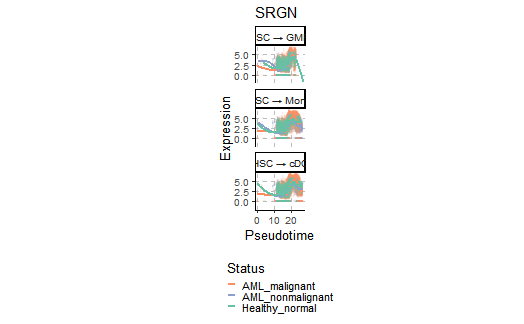

```r
plot_pseudotime("SRGN", file_suffix="plot/other/scrna_pseudo_")
```

- 43/61 was selected for association with immune/myeloid/aml related genes
- plotting only cdc and mono lineage; keeping gmp as supplement

```r
png("plot/fig6/main_6f_hm_lineage_1_2.png", width = 9.5, height = 7.5, units = "in", res = 600, bg="transparent", family = "Arial")
# Cairo::CairoPDF("plot/fig6/main_6f_hm_lineage_1_2.pdf", width = 9.5, height = 7.5, bg="transparent", family = "Arial")
ComplexHeatmap::draw(hm2 + hm1, auto_adjust = F, ht_gap = unit(-1,"mm"), merge_legends = T, background = "transparent")
```

```r
n = 3 # change to 3 for supp figure
df_1 <- df
df_1$Lineage <- pseudotime_df[,n]
df_1 <- df_1 %>% filter(!is.na(Lineage)) %>% arrange(Lineage)

ha1 <- columnAnnotation(
  cell_status = df_1$cell_status,
  celltype = df_1$CellType,
  col = list(
    cell_status = color_celltype,
    celltype = hierarchy_colors[c(1,2,5:16)]
  ),
  show_annotation_name = T
)

mat <- df_1[,selected_gene$gene] %>% as.matrix() %>% t()

hm2 <- Heatmap(
  mat, top_annotation = ha1, col = col_fun, border_gp = gpar(col = "grey30"),
  show_row_dend = F, show_column_dend = F,
  show_column_names = F, cluster_columns = F,
  cluster_rows = T, clustering_distance_rows = "euclidean",
  column_split = df_1$cell_status, column_title = lineage_level[n],
  row_split = selected_gene$category, row_title_rot = 0, row_title_gp = gpar(fontsize = 11),
  cluster_row_slices = F, row_names_centered = F,
  name = "scaled", use_raster = T, raster_device = "png", raster_quality = 3,
  heatmap_legend_param = list(border = "black", labels_gp = gpar(fontsize = 10))
)

# png("plot/suppfig7/supp_7e_hm_lineage_3.png", width = 7, height = 7.5, units = "in", res = 600, bg="transparent")
Cairo::CairoPDF("plot/suppfig7/supp_7e_hm_lineage_3.pdf", width = 7, height = 7.5, bg="transparent", family = "Arial")
ComplexHeatmap::draw(hm2, merge_legends = T, background = "transparent")
```